# Usuarios de Netflix

### Autor: Christian Jaime

### Fuente: https://www.kaggle.com/datasets/arnavsmayan/netflix-userbase-dataset

El set de datos seleccionado es una muestra de la base de usuarios de Netflix y contiene el tipo de suscripción, género, edad, país, fecha de la suscripción, etc.

Con el mismo se intentará encontrar patrones de los sucriptores, tales como algún género, edad o nacionalidad dominante en la plataforma.

Otro aspecto interesante será poder ver cuánto tiempo llevan en la plataforma los usuarios, lo que dará una idea del éxito de la misma.

```python
import pandas as pd
import numpy as np
import plotly.express as px
import matplotlib.pyplot as plt
import seaborn as sns
from datetime import datetime
```

```python
data = pd.read_csv('Netflix Userbase.csv')
data[0:5]
```

|  | User ID | Subscription Type | Monthly Revenue | Join Date | Last Payment Date | Country | Age | Gender | Device | Plan Duration |
| --- | --- | --- | --- | --- | --- | --- | --- | --- | --- | --- |
| 0 | 1 | Basic | 10 | 15-01-22 | 10-06-23 | United States | 28 | Male | Smartphone | 1 Month |
| 1 | 2 | Premium | 15 | 05-09-21 | 22-06-23 | Canada | 35 | Female | Tablet | 1 Month |
| 2 | 3 | Standard | 12 | 28-02-23 | 27-06-23 | United Kingdom | 42 | Male | Smart TV | 1 Month |
| 3 | 4 | Standard | 12 | 10-07-22 | 26-06-23 | Australia | 51 | Female | Laptop | 1 Month |
| 4 | 5 | Basic | 10 | 01-05-23 | 28-06-23 | Germany | 33 | Male | Smartphone | 1 Month |

### Género

En primer lugar se analizará el número de suscriptores por género para determinar si hay uno dominante.

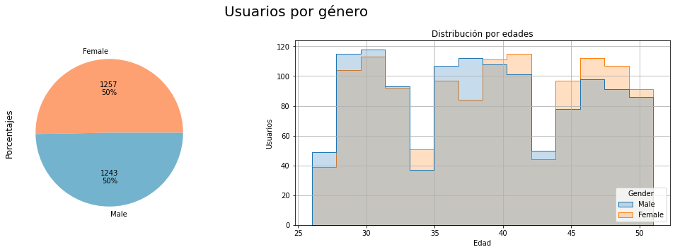

```python
fig, axes = plt.subplots(1, 2, figsize=(15, 5))
fig.suptitle('Usuarios por género', fontsize=20)

def percent(val):
    return f'{val / 100 * len(data):.0f}\n{val:.0f}%'

data.groupby('Gender').size().plot(kind='pie', autopct=percent, textprops={'fontsize': 10},
                                   colors=['#fda172', '#74b3ce'], ax=axes[0])
axes[0].set_ylabel('Porcentajes', size=12)
g = sns.histplot(ax=axes[1], data=data, x="Age", hue="Gender", element="step")
g.set(title='Distribución por edades')
sns.move_legend(g, "lower right")
axes[1].set(xlabel='Edad',ylabel='Usuarios')
plt.tight_layout()
plt.grid()
plt.show()
```

De los gráficos podemos ver que no hay dominio de algún género, la distribución está 50%-50%, sin embargo, lo que sí se puede notar del histograma de edades, es que conforme aumenta la edad, el número de usuarios mujeres supera el número de usuarios hombres.

### Nacionalidad

Ahora seguiremos con los países para encontrar a los que tienen mayor número de suscriptores

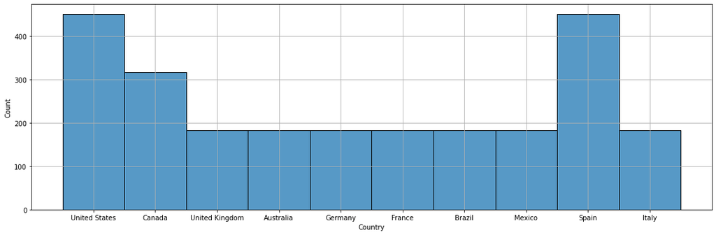

```python
fig, axes = plt.subplots(1, figsize=(15, 5))
sns.histplot(data=data,x="Country")
plt.tight_layout()
plt.grid()
plt.show()
```

Del histograma podemos identificar que los 3 países con más usuarios son Estados Unidos, España y Canada, el resto comparte el mismo número de usuarios, lo que podría indicar que el set de datos es de prueba.

Siguiendo con el estudio por país, ahora se identificará el tipo de suscripciones de cada país.

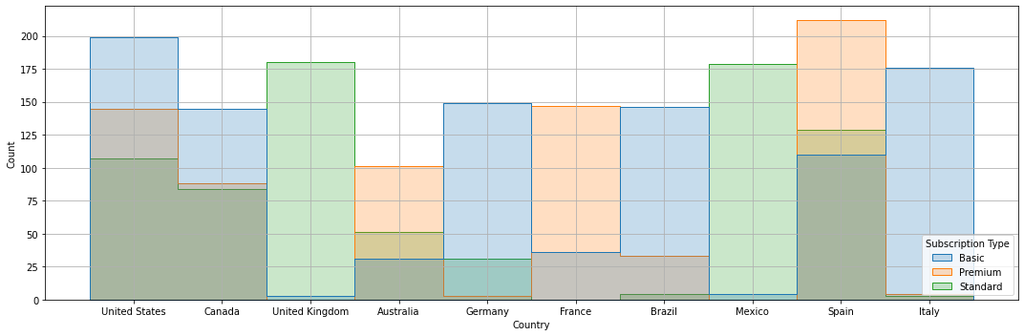

```python
fig, axes = plt.subplots(1, figsize=(15, 5))
g = sns.histplot(data=data,x="Country", hue="Subscription Type", element="step")
sns.move_legend(g, "lower right")
plt.tight_layout()
plt.grid()
plt.show()
```

Del gráfico anterior podemos ver que España es el país con más suscripciones Premium, mientras que Estados Unidos es el que más suscripciones Basic tiene. El Reino Unido y México prácticamente sólo tienen usuarios Standard mientras que en Italia dominan las suscripciones Basic.

### Antigüedad

Aunque no tenemos la antigüedad como parte de los datos, podemos usar la fecha de inscripción y la fecha del último pago de los usuarios para calcularla.

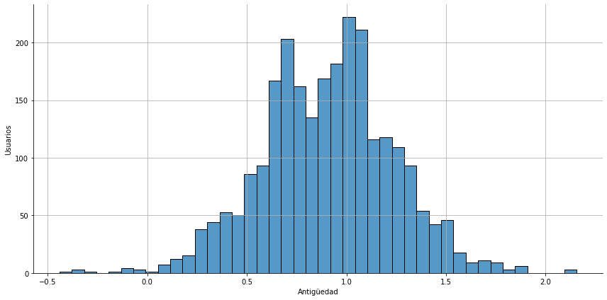

```python
data['Last Payment Date'] = pd.to_datetime(data['Last Payment Date'])
data['Join Date'] = pd.to_datetime(data['Join Date'])

data['Antiguedad'] = ((data['Last Payment Date'] - data['Join Date']).dt.days)/30/12

g = sns.displot(data=data, x="Antiguedad", height=6, aspect=2,)
g.set_axis_labels("Antigüedad","Usuarios")
plt.grid()
plt.show()
```

La información más interesante hasta ahora, viene de la distribución de la antigüedad. Del gráfico podemos observar que la lealtad a la plataforma dura como máximo 2 años, algo decepcionante para un servicio que inició su servicio de streaming desde 2008. Sin embargo, un detalle a considerar, es que existen usuarios con antigüedad negativa, lo que refuerza la idea de que el dataset sólo es de prueba.

### Dispositivos

Un aspecto que podría mostrar algún patrón es poder relacionar la edad con los dispositivos con los que los usuarios hacen uso del servicio.

```python
df = data[['Antiguedad','Age','Device']].copy()

df = df.replace(to_replace="Tablet",value=1)
df = df.replace(to_replace="Smartphone",value=2)
df = df.replace(to_replace="Smart TV",value=3)
df = df.replace(to_replace="Laptop",value=4)


fig = px.parallel_coordinates(df, color="Device",labels={"Country": "Country",
                "Age": "Age", "Antiguedad": "Antiguedad",
                "Monthly Revenue": "Monthly Revenue", })
fig.show()
```

[interactive chart not shown]

No se puede ver un patrón claro del gráfico de ejes coordinados paralelos, se esperaba ver grupos de líneas juntas que mostraran alguna tendencia en el uso de dispositvos, edad y/o antigüedad. Esto sigue sumando a la idea de estar usando un set de datos de prueba.

Un detalle que puede rescatarse del gráfico es que fácilmente se puede ver que los 3 usuarios con mayor antigüedad usan dispositivos diferentes (Smart TV, Laptop y Smartphone), el usuario más nuevo (que incluso tiene antigüedad negativa) usa una Tablet.

### Anexo

Debido a que para leer un archivo csv usando D3 es necesario montar un servidor local, por practicidad se optó por procesar el set de datos usando Python para crear archivos .js que puedan ser leídos sin la necesidad del servidor.

Las funciones son las siguientes

```python
#Función para generar los datos usados en el histograma con D3

import csv
import json

def convert_csv_to_dict(csv_file_path, json_file_path):
    data = []
    with open(csv_file_path, 'r') as csv_file:
        csv_reader = csv.DictReader(csv_file)
        for row in csv_reader:
            data.append(row)

    with open(js_file_path, 'w') as js_file:
        js_file.write("data =" + json.dumps(data, indent=4))

    print("CSV to DICT conversion complete.")

# Example usage
csv_file_path = 'Netflix Userbase.csv'
js_file_path = 'Netflix_Userbase_data.js'
convert_csv_to_dict(csv_file_path, js_file_path)
```

```
CSV to DICT conversion complete.
```

```python
#Función para generar los datos usados en el gráfico Sunburst con D3

import csv
import json

def convert_row_to_string(row, column_order):
    values = []
    for column in column_order:
        value = row.get(column, "")
        values.append(str(value))
    return '_'.join(values)

def convert_csv_to_js(csv_file_path, js_file_path, column_order):
    data = []
    with open(csv_file_path, 'r') as csv_file:
        csv_reader = csv.DictReader(csv_file)
        for row in csv_reader:
            converted_row = convert_row_to_string(row, column_order)
            data.append(converted_row)

    with open(js_file_path, 'w') as js_file:
        js_file.write("data =" + json.dumps(data, indent=4))

    print("CSV to JS conversion complete.")

# Example usage
csv_file_path = 'Netflix Userbase.csv'
js_file_path = 'sunburst/Netflix_Userbase_sunburst.js'
column_order = ['Country','Gender','Subscription Type','Device',]

convert_csv_to_js(csv_file_path, js_file_path, column_order)
```

```
CSV to JS conversion complete.
```

### Referencias

Netflix Userbase Data Visualization : https://www.kaggle.com/code/pritamnarwade/netflix-userbase-data-visualization Sunburst: https://observablehq.com/@kerryrodden/sequences-sunburst